# T8_Solution

### TCX3212 Predictive Analytics

### Tutorial/Lab 8

Learning Objectives

- Understand and Apply Exponential Smoothing
- Understand and Apply Holt-Winters Forecasting
- Evaluate forecast accuracy

```python
# 1. Import libraries
import pandas as pd
import matplotlib.pyplot as plt
from statsmodels.tsa.holtwinters import ExponentialSmoothing

%matplotlib inline
plt.rcParams["figure.figsize"] = (12, 6)
```

```python
# In JupyterLab, first navigate to the directory containing College.csv
import os
os.chdir('C:/Users/sowjs/NUS Dropbox/Jin Sze Sow/Jin Sze Sow’s files/Home/BIT TCX 3212 Predictive Analytics/AY2526S2/Tutorial/T8')  # Replace with your actual path
```

#### Simple Exponential Smoothing

1. In this exercise, you will analyze and forecast annual oil production in Saudi Arabia using Simple Exponential Smoothing (SES).

a) Load Oil.csv and convert the Year column to a datetime format. Set it as the index and create a pandas Series with a yearly frequency. Plot the original time series. Describe any trends or patterns you notice in the data.

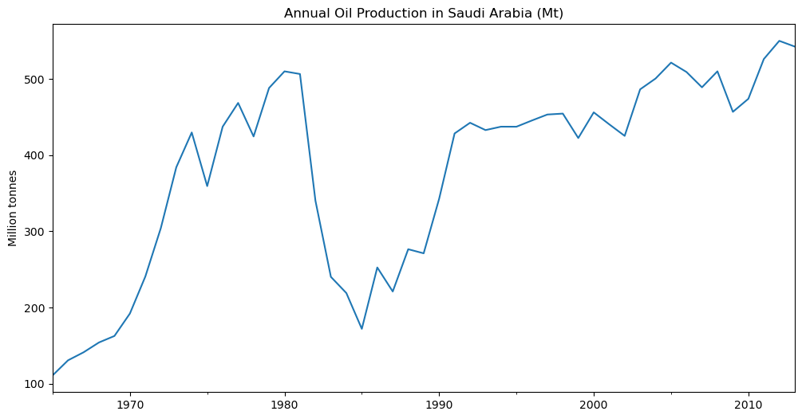

```python
# Assume oil.csv has two columns: "Year" and "Production"
oil_df = pd.read_csv("Oil.csv")

# Convert 'Year' to datetime and set as index
oil_df['Year'] = pd.to_datetime(oil_df['Year'], format='%Y')
oil_df.set_index('Year', inplace=True)


# Create a pandas Series
oil = oil_df['Production']

# Create pandas Series with yearly frequency
oil = pd.Series(oil, index=pd.date_range("1965", "2013", freq="YS"))


# Plot original data
oil.plot(title="Annual Oil Production in Saudi Arabia (Mt)")
plt.ylabel("Million tonnes")
plt.show()
```

There is a general upward trend in oil production from 1965 to 2013.

Some years show sharp increases or decreases, possibly due to geopolitical or economic events.

Seasonal variation is not present, which makes sense since this is annual data.

b) Fit a Simple Exponential Smoothing (SES) model to the data. Experiment with different smoothing levels (e.g., α = 0.2, α = 0.5, α = 0.8). Plot the fitted values for each α on the same graph and compare them. Discuss how changing α affects the smoothness of the series and the responsiveness to recent trends.

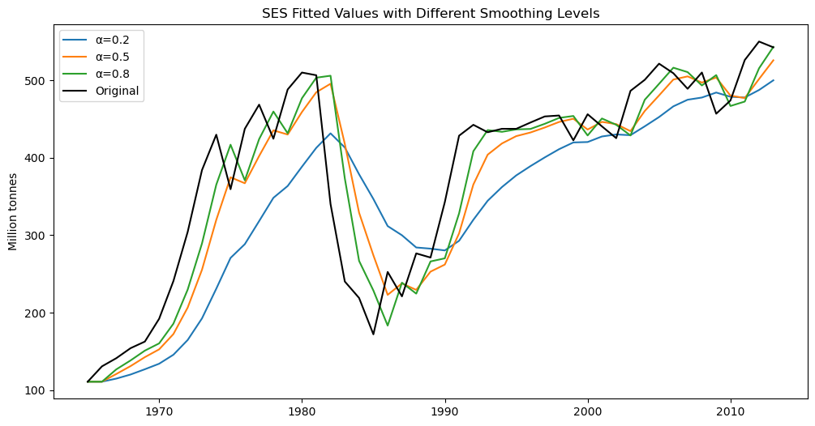

```
            Original     SES_0.2     SES_0.5     SES_0.8
1965-01-01  111.0091  111.009100  111.009100  111.009100
1966-01-01  130.8284  111.009100  111.009100  111.009100
1967-01-01  141.2871  114.972960  120.918750  126.864540
1968-01-01  154.2278  120.235788  131.102925  138.402588
1969-01-01  162.7409  127.034190  142.665363  151.062758
1970-01-01  192.1665  134.175532  152.703131  160.405272
1971-01-01  240.7997  145.773726  172.434816  185.814254
1972-01-01  304.2174  164.778921  206.617258  229.802611
1973-01-01  384.0046  192.666617  255.417329  289.334442
1974-01-01  429.6622  230.934213  319.710964  365.070568
1975-01-01  359.3169  270.679811  374.686582  416.743874
1976-01-01  437.2519  288.407228  367.001741  370.802295
1977-01-01  468.4008  318.176163  402.126821  423.961979
1978-01-01  424.4353  348.221090  435.263810  459.513036
1979-01-01  487.9794  363.463932  429.849555  431.450847
1980-01-01  509.8284  388.367026  458.914478  476.673689
1981-01-01  506.3473  412.659301  484.371439  503.197458
1982-01-01  340.1842  431.396900  495.359369  505.717332
1983-01-01  240.2589  413.154360  417.771785  373.290826
1984-01-01  219.0328  378.575268  329.015342  266.865285
```

```python
from statsmodels.tsa.holtwinters import SimpleExpSmoothing

alphas = [0.2, 0.5, 0.8]
fitted_values = {}

plt.figure(figsize=(12,6))
for alpha in alphas:
    ses = SimpleExpSmoothing(oil).fit(smoothing_level=alpha, optimized=False)
    fitted_values[alpha] = ses.fittedvalues
    plt.plot(ses.fittedvalues, label=f'α={alpha}')

plt.plot(oil, label='Original', color='black')
plt.title('SES Fitted Values with Different Smoothing Levels')
plt.ylabel('Million tonnes')
plt.legend()
plt.show()

comparison_df = pd.DataFrame({'Original': oil})

for alpha in alphas:
    comparison_df[f'SES_{alpha}'] = fitted_values[alpha]

print(comparison_df.head(20))
```

Simple Exponential Smoothing (SES) is a time series technique used to smooth data and produce short-term forecasts. The central idea is to create a weighted average of past observations, where the weights decay exponentially as we move further into the past.

- The smoothing parameter 𝛼 α determines how much weight is given to the most recent observation relative to the past smoothed values.
- α = 0.2 → 20% weight on the current observation, 80% on the past. Observed a very smooth fitted line. Slow to react to recent changes, follows long-term trend. Short-term fluctuations are largely ignored, this is ideal for noisy data where you care about long-term trends.
- α = 0.5 → Equal weight to the current observation and past smoothed value, hence a balanced response. Captures trend moderately, some responsiveness to recent changes. Produces a moderately responsive curve. Useful when you want a balance between smoothing and responsiveness
- α = 0.8 → 80% weight on the current observation, only 20% on the past. Fitted line reacts quickly to recent fluctuations. More sensitive, less smooth. The fitted line responds quickly to changes But, it can overreact to noise. Best for data that changes rapidly or where recent observations are more important

Smaller α → smoother, ignores short-term changes. the estimate retains influence from many past observations.

Larger α → more responsive to recent changes, but may overreact to random fluctuations.

c) Using α = 0.9, generate a 5-year forecast.

```python
# Fit model
ses_model = SimpleExpSmoothing(oil).fit(
    smoothing_level=0.9,
    optimized=False
)

## Convert integer years to a PeriodIndex (annual frequency)
if not isinstance(oil.index, (pd.DatetimeIndex, pd.PeriodIndex)):
        oil.index = pd.PeriodIndex(oil.index, freq='A')

# Forecast 5 years
ses_forecast = ses_model.forecast(5)
print(ses_forecast)

fitted_values = ses_model.fittedvalues

# Print with year if your index is annual
# for year, value in fitted_values.items():
#    print(f"{year.year}, Fitted: {value:.2f}")
```

```
2014    542.79767
2015    542.79767
2016    542.79767
2017    542.79767
2018    542.79767
Freq: Y-DEC, dtype: float64
```

d) Calculate the RMSE between the fitted values and the actual data for each α. Which α gives the lowest error? Does the lowest RMSE always correspond to the “best” forecast visually? Explain.

```python
from statsmodels.tsa.holtwinters import SimpleExpSmoothing
from sklearn.metrics import mean_squared_error
import numpy as np

alphas = [0.2, 0.5, 0.8]
rmse_values = {}

for alpha in alphas:
    ses_model = SimpleExpSmoothing(oil).fit(smoothing_level=alpha, optimized=False)
    fitted = ses_model.fittedvalues
    rmse = np.sqrt(mean_squared_error(oil, fitted))
    rmse_values[alpha] = rmse

print(rmse_values)
```

```
{0.2: np.float64(90.36209039724527), 0.5: np.float64(62.15778392244679), 0.8: np.float64(51.13987791473321)}
```

Higher α gives lower RMSE because it reacts faster to recent changes in the series.

Lowest RMSE (α = 0.8) does not always produce the best forecast visually:

High α may overfit short-term fluctuations, making the forecast volatile.

Medium α may provide a smoother, more realistic forecast.

#### Holt-winter Forecasting

2. In this exercise, you will load, visualize, and analyze a quarterly time series of Australian tourist arrivals from March 1999 – Dec 2015. You will perform decomposition to understand trends, seasonality, and select an appropriate model for forecasting. You will be using the Austourists (Austourists.csv) data set which can be downloaded from Canvas.

a) Load Austourists.csv, convert Date column to datetime. Set the Date column as the index and ensure it has a quarterly frequency and plot the time series. Describe the observed trend and seasonal patterns.

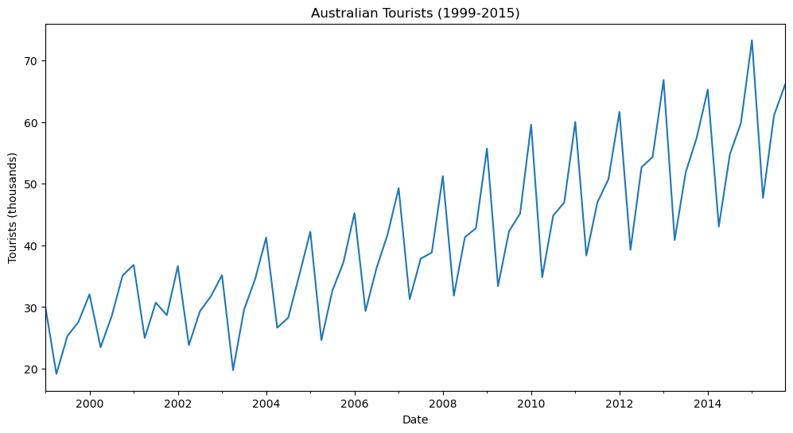

```python
# ==============================
# 1. Import libraries
# ==============================
import pandas as pd
import matplotlib.pyplot as plt
from statsmodels.tsa.seasonal import seasonal_decompose

# ==============================
# 2. Load your data
# ==============================
# Assume your CSV has columns "Date" and "Tourists"
austourists_df = pd.read_csv("Austourists.csv")

# Convert Date to datetime and set as index
austourists_df['Date'] = pd.to_datetime(austourists_df['Date'], format='%d/%m/%Y')

# Set Date as index
austourists_df.set_index('Date', inplace=True)

# Ensure the index has a formal Quarterly Frequency (Quarter Start)
austourists = austourists_df['Tourists'].asfreq('QS')

# Create Series
austourists = austourists_df['Tourists']

# ==============================
# 3. Plot original data
# ==============================
austourists.plot(title="Australian Tourists (1999-2015)", ylabel="Tourists (thousands)")
plt.show()
```

b) Decompose the training time series using both additive and multiplicative decomposition methods. Plot the trend, seasonal, and residual components for both. Compare the results and explain which decomposition better fits the data, and why.

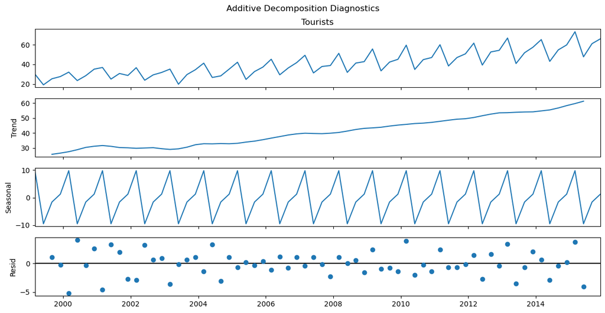

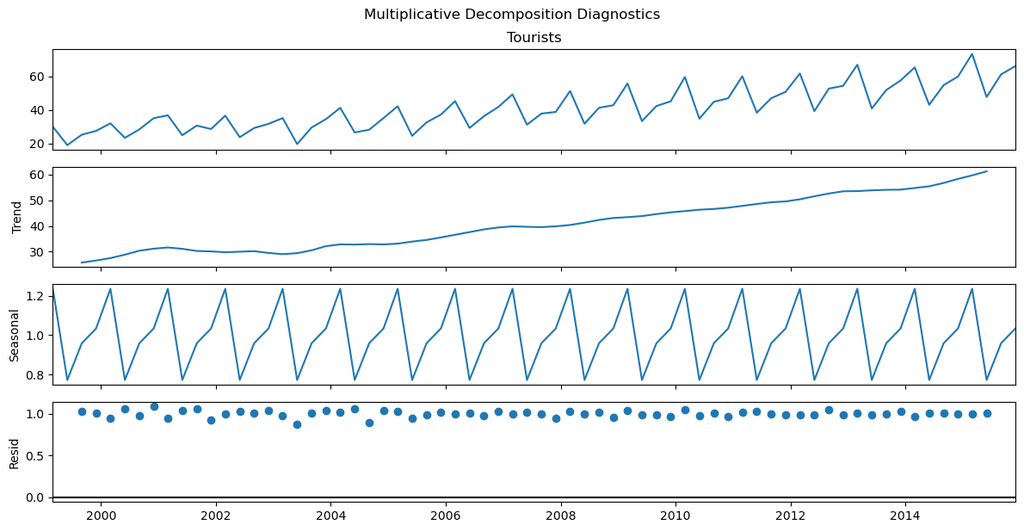

```python
# Perform decompositions
# Note: period=4 for quarterly data
decomposition_add = seasonal_decompose(austourists, model='additive')
decomposition_mul = seasonal_decompose(austourists, model='multiplicative')

# Extract trend component
trend = decomposition_add.trend

# Save to CSV
trend.to_csv("austourists_trend.csv")
#print(decomposition_add.trend)

# Plot Additive
fig_add = decomposition_add.plot()
fig_add.suptitle("Additive Decomposition Diagnostics", fontsize=12, y=1.02)
plt.show()

# Plot Multiplicative
fig_mul = decomposition_mul.plot()
fig_mul.suptitle("Multiplicative Decomposition Diagnostics", fontsize=12, y=1.02)
plt.show()
```

c) Partition the data into a training set and a validation set. Use all data up to December 2014 as the training set and the last four quarters (2015) as the validation set. Explain why it is important to separate the data for training and validation.

```python
# Partitioning the data
train = austourists[:'2014-12-31']
validation = austourists['2015-01-01':]

print(f"Training observations: {len(train)}")
print(f"Validation observations: {len(validation)}")
```

```
Training observations: 64
Validation observations: 4
```

d) Using the training set, fit a Holt-Winters (Triple Exponential Smoothing) model with an Additive Trend and Additive Seasonality. Apply the following fixed smoothing parameters: Smoothing Level (alpha): 0.3 Smoothing Trend (beta): 0.1 Smoothing Seasonal (gamma): 0.2

```python
from statsmodels.tsa.holtwinters import ExponentialSmoothing
import numpy as np
from sklearn.metrics import mean_squared_error
# ==============================================================
# 4. Fit Holt-Winters Model (Additive Trend + Additive Seasonality)
# ==============================================================
# Using the training data partitioned in Step C
hw_model = ExponentialSmoothing(
    train,
    trend="add",          # Assumes a constant linear trend
    seasonal="add",       # Assumes a constant seasonal fluctuation
    seasonal_periods=4    # Quarterly frequency
)

# Fit model with the specific parameters provided in the question
hw_fit = hw_model.fit(
    smoothing_level=0.3,    # Alpha
    smoothing_trend=0.1,    # Beta
    smoothing_seasonal=0.2, # Gamma
    optimized=False         # Required to force the use of our specific values)
)
```

e) Generate a forecast for the four quarters of 2015.

```python
# ==============================
# 5. Forecast next 12 months (next year)
# ==============================
forecast_steps = 4  # one year ahead (quarterly data)
hw_forecast = hw_fit.forecast(forecast_steps)

# Optional: Ensure the index is clean for your lab report
hw_forecast.index = pd.date_range(start="2015-01-01", periods=4, freq='QS')

print("--- 2015 Forecast ---")
print(hw_forecast)
```

```
--- 2015 Forecast ---
2015-01-01    68.640729
2015-04-01    46.871600
2015-07-01    57.462445
2015-10-01    60.762852
Freq: QS-JAN, dtype: float64
```

f) Calculate the Root Mean Squared Error (RMSE) for your forecasts and explain what it tells you. Then, calculate the MAPE (Mean Absolute Percentage Error) for each quarter of 2015 and interpret the results.

```python
from sklearn.metrics import mean_squared_error
rmse = np.sqrt(mean_squared_error(validation, hw_forecast))
print(f"Validation RMSE: {rmse:.2f}")
```

```
Validation RMSE: 3.98
```

```python
# 2. Calculate Individual Quarter Errors (MAPE)
# We create a table to show the 'Absolute Percentage Error' for each quarter
quarterly_analysis = pd.DataFrame({
    'Actual': validation.values,
    'Forecast': hw_forecast.values
}, index=['2015 Q1', '2015 Q2', '2015 Q3', '2015 Q4'])

# Calculate the Absolute Percentage Error (APE) for each row
quarterly_analysis['APE (%)'] = np.abs((quarterly_analysis['Actual'] - quarterly_analysis['Forecast']) / quarterly_analysis['Actual']) * 100

# 3. Output results
print(f"Overall Validation RMSE: {rmse:.2f}")
print("\n--- Individual Quarter Analysis ---")
print(quarterly_analysis[['Actual', 'Forecast', 'APE (%)']])

# Calculate the mean of these for the overall MAPE
overall_mape = quarterly_analysis['APE (%)'].mean()
print(f"\nOverall Mean Absolute Percentage Error (MAPE): {overall_mape:.2f}%")
```

```
Overall Validation RMSE: 3.98

--- Individual Quarter Analysis ---
            Actual   Forecast   APE (%)
2015 Q1  73.257027  68.640729  6.301509
2015 Q2  47.696624  46.871600  1.729732
2015 Q3  61.097768  57.462445  5.950009
2015 Q4  66.055761  60.762852  8.012790

Overall Mean Absolute Percentage Error (MAPE): 5.50%
```

g) Plot the forecast and the fitted training values against the actual validation data.

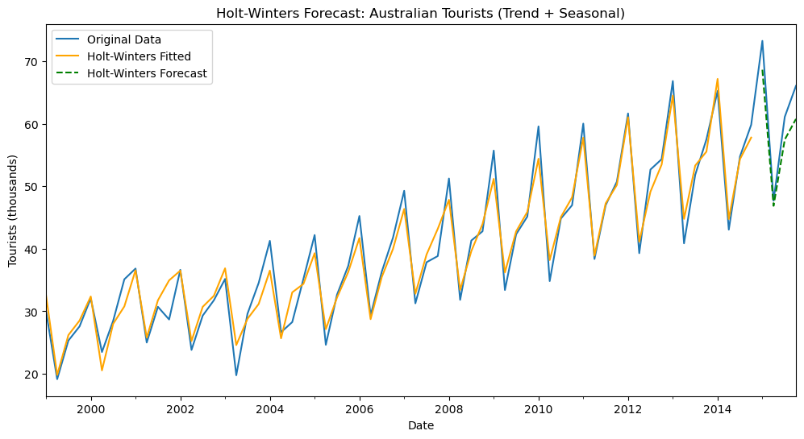

```python
# ==============================
# 6. Plot original data, fitted values, and forecast
# ==============================
fig, ax = plt.subplots(figsize=(12,6))
austourists.plot(ax=ax, label="Original Data")
hw_fit.fittedvalues.plot(ax=ax, label="Holt-Winters Fitted", color="orange")
hw_forecast.plot(ax=ax, label="Holt-Winters Forecast", style="--", color="green")
ax.set_title("Holt-Winters Forecast: Australian Tourists (Trend + Seasonal)")
ax.set_ylabel("Tourists (thousands)")
ax.legend()
plt.show()
```